# AImsII

Irenaeus Wolff

2026-02-06

```r
library(dplyr)
library(Exact)
library(fixest)
library(ggplot2)
library(tidyr)
library(texreg)
library(scales)
```

### Load data

```r
# load cleaned dataset
choices <- read.delim("~/work/zz_nextcloud/y_AImsAndAixperience/Experiments/ProlificData/files_Fri_02-06-2026_15-28-25-48/260206_1528_537_lotteryChoices.xls")
choicesP1 <- subset(choices, Part == 1)
subjects <- read.csv("~/work/zz_nextcloud/y_AImsAndAixperience/Experiments/ProlificData/files_Fri_02-06-2026_15-28-25-48/allSubjects.csv", header = T)
prolificData <- read.csv("~/work/zz_nextcloud/y_AImsAndAixperience/Experiments/ProlificData/files_Fri_02-06-2026_15-28-25-48/prolific_demographic_export_approved.csv")
```

### Exclude observations based on preregistration

```r
prolificData$logCompleTime <- log(prolificData$Time.taken)
prolificData$tooFast <- 1*(prolificData$logCompleTime < mean(log(prolificData$Time.taken)) - 2*sd(log(prolificData$Time.taken)))

choices <- subset(choices, BotCheck1attempt == 1 & Part1CQsPassedOnAttempt <= 2 & Part2CQsPassedOnAttempt <= 2 & Reliable >= 6 & AIUsageInStudy == 0 & Delegated >= 0 & ProlificID %in% prolificData$Participant.id[prolificData$tooFast == 0])
subjects <- subset(subjects, ProlificID %in% choices$ProlificID)
choicesP1 <- subset(choicesP1, ProlificID %in% choices$ProlificID)
table(subjects$EVAlgorithm)
```

```
##
##   0   1
## 115 118
```

```r
# STILL TO BE DONE: Exclusion by log time (-> TotalSecondsInExperiment)
```

### overview delegation and (non-)dominated choices

```r
choices <- choices %>%
  mutate(Algorithm = ifelse(EVAlgorithm == 1, "EV", "Pref"))

choicesAv <- choices %>%
  filter(Part == 2) %>%
    group_by(Algorithm, Part, WithinPartDecisionNumber) %>%
    summarise(
      avDeleg = mean(Delegated, na.rm = T),
      avNonDom = mean( Nondominated[Delegated == 0 & Option > 0], na.rm = T)
  )
choicesAv
```

| Algorithm | Part | WithinPartDecisionNumber | avDeleg | avNonDom |
| --- | --- | --- | --- | --- |
| EV | 2 | 1 | 0.6694915 | 0.3421053 |
| EV | 2 | 2 | 0.5254237 | 0.2142857 |
| EV | 2 | 3 | 0.4741379 | 0.3000000 |
| EV | 2 | 4 | 0.5299145 | 0.3333333 |
| EV | 2 | 5 | 0.4322034 | 0.2686567 |
| EV | 2 | 6 | 0.4152542 | 0.4637681 |
| EV | 2 | 7 | 0.4913793 | 0.3559322 |
| EV | 2 | 8 | 0.4827586 | 0.4333333 |
| Pref | 2 | 1 | 0.5575221 | 0.4000000 |
| Pref | 2 | 2 | 0.5350877 | 0.3269231 |

[output cut: 6 more lines]

```r
choices %>%
  filter(Part == 2) %>%
    group_by(Algorithm) %>%
    summarise(
      avNonDom = mean( Nondominated[Delegated == 0 & Option > 0], na.rm = T)
  )
```

| Algorithm | avNonDom |
| --- | --- |
| EV | 0.3412527 |
| Pref | 0.3505376 |

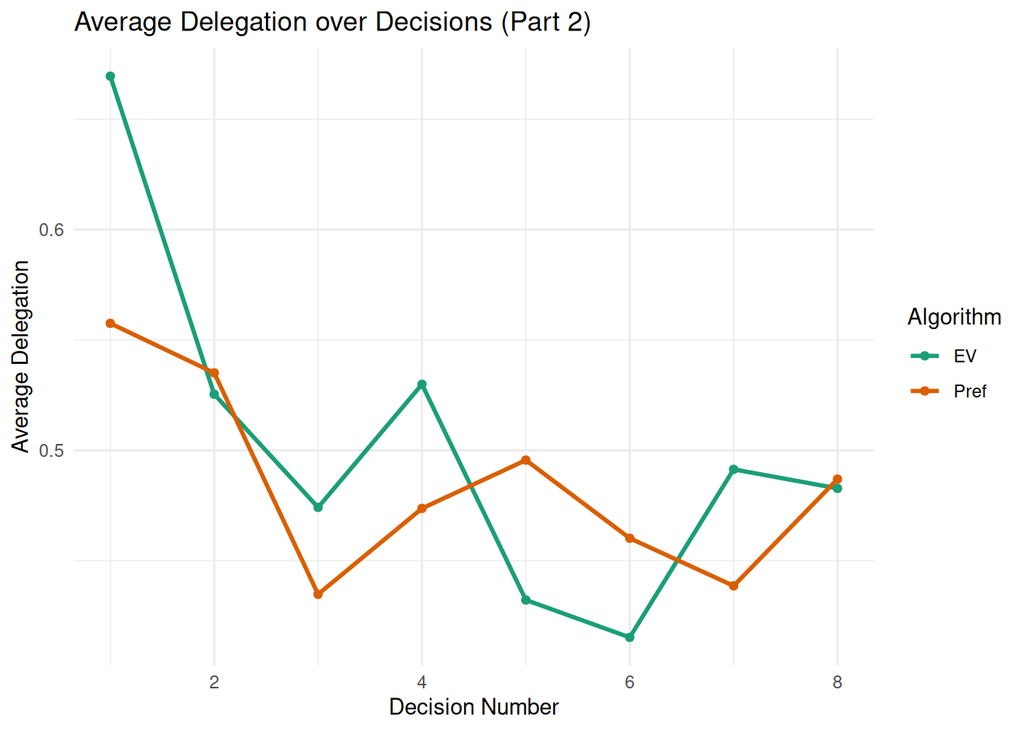

```r
choicesAv %>%
  ggplot(aes(
    x = WithinPartDecisionNumber,
    y = avDeleg,
    color = factor(Algorithm),
    group = Algorithm
  )) +
  geom_line(linewidth = 1) +
  geom_point() +
  labs(
    x = "Decision Number",
    y = "Average Delegation",
    color = "Algorithm",
    title = "Average Delegation over Decisions (Part 2)"
  ) + scale_color_brewer(palette = "Dark2") +
#   scale_color_manual(
#     values = c("#4E79A7", "#59A14F")
# ) +
  theme_minimal()
```

NB: at least 65% suboptimal choices without delegation

### Hypothesis testing

```r
tab <- table(
  Delegated = choices$Delegated[choices$Part == 2 & choices$WithinPartDecisionNumber == 1],
  EVAlgorithm = choices$EVAlgorithm[choices$Part == 2 & choices$WithinPartDecisionNumber == 1]
)

prop.table(tab, margin = 2)
```

```
##          EVAlgorithm
## Delegated         0         1
##         0 0.4424779 0.3305085
##         1 0.5575221 0.6694915
```

```r
exact.test(tab, method = "Boschloo", alternative = "greater", to.plot = F)$p.value
```

```
## [1] 0.0412565
```

```r
delegAv <- choices %>%
  filter(Part == 2) %>%
    group_by(Algorithm, ProlificID) %>%
    summarise(
      avDeleg = mean(Delegated, na.rm = T),
  ) %>% mutate(Algorithm = factor(Algorithm, levels = c("Pref", "EV")))
```

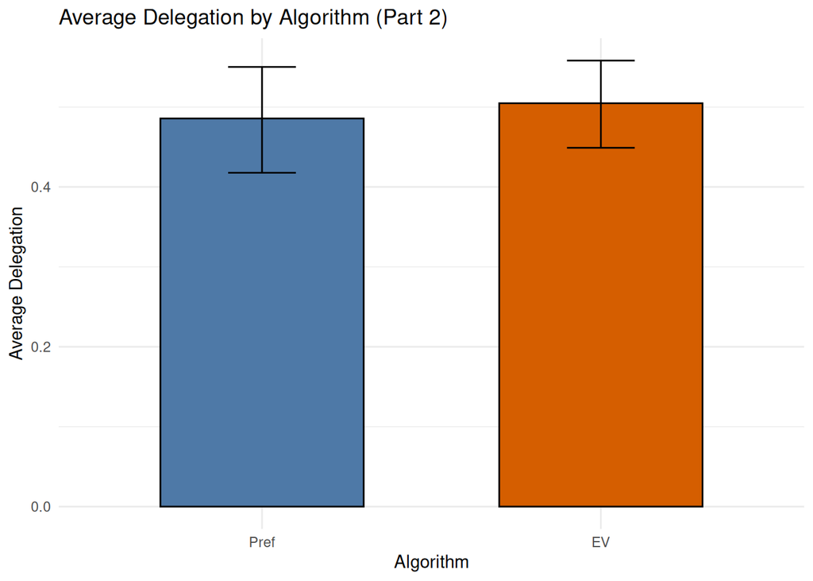

```r
delegAv %>%
  ggplot(aes(x = Algorithm, y = avDeleg, fill = Algorithm)) +
  stat_summary(
    fun = mean,
    geom = "bar",
    width = 0.6,
    color = "black"
  ) +
  stat_summary(
    fun.data = mean_cl_boot,
    geom = "errorbar",
    width = 0.2
  ) +
  scale_fill_manual(
    values = c("Pref" = "#4E79A7", "EV" = "#D55E00")
  ) +
  labs(
    x = "Algorithm",
    y = "Average Delegation",
    title = "Average Delegation by Algorithm (Part 2)"
  ) +
  theme_minimal() +
  theme(legend.position = "none")
```

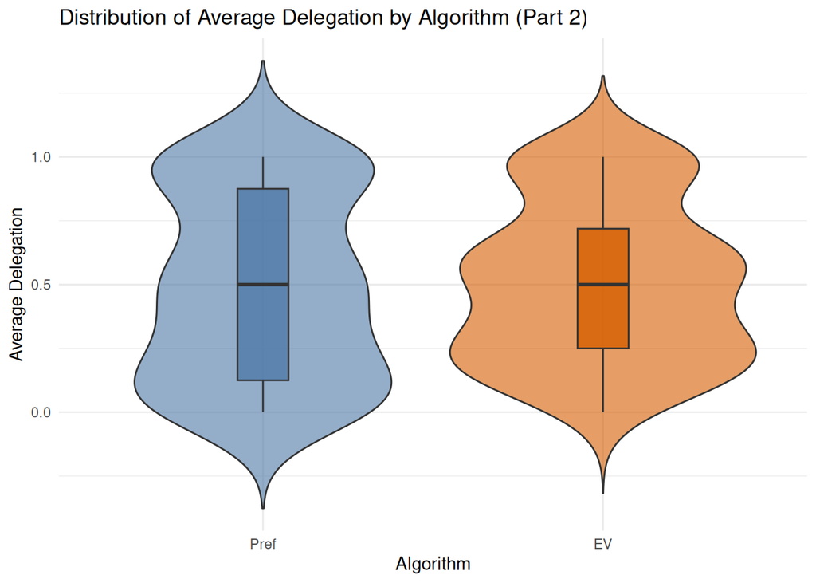

```r
delegAv %>%
  ggplot(aes(x = Algorithm, y = avDeleg, fill = Algorithm)) +
  geom_violin(trim = FALSE, alpha = 0.6) +
  geom_boxplot(
    width = 0.15,
    outlier.shape = NA,
    alpha = 0.8
  ) +
  scale_fill_manual(
    values = c("Pref" = "#4E79A7", "EV" = "#D55E00")
  ) +
  labs(
    x = "Algorithm",
    y = "Average Delegation",
    title = "Distribution of Average Delegation by Algorithm (Part 2)"
  ) +
  theme_minimal() +
  theme(legend.position = "none")
```

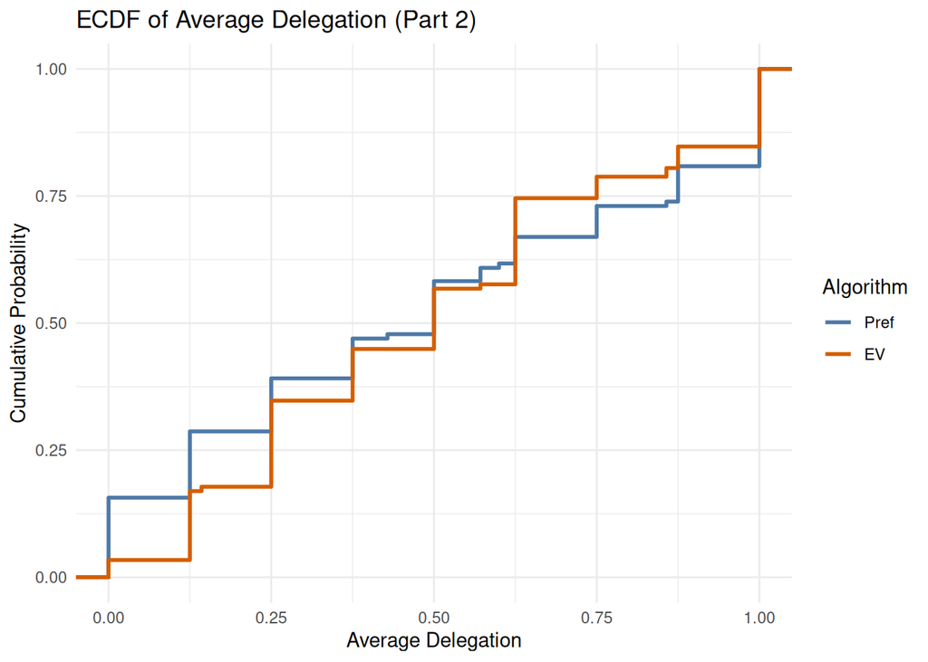

```r
delegAv %>%
  ggplot(aes(x = avDeleg, color = Algorithm)) +
  stat_ecdf(linewidth = 1) +
  scale_color_manual(
    values = c("Pref" = "#4E79A7", "EV" = "#D55E00")
  ) +
  labs(
    x = "Average Delegation",
    y = "Cumulative Probability",
    color = "Algorithm",
    title = "ECDF of Average Delegation (Part 2)"
  ) +
  theme_minimal()
```

```r
wilcox.test(
  avDeleg ~ Algorithm,
  data = delegAv,
  alternative = "less"
)
```

```
##
##  Wilcoxon rank sum test with continuity correction
##
## data:  avDeleg by Algorithm
## W = 6428, p-value = 0.2425
## alternative hypothesis: true location shift is less than 0
```

```r
# LPM with FE and cluster
delReg <- feols(
  Delegated ~ EVAlgorithm*WithinPartDecisionNumber | OptionsetID,
  cluster = ~ProlificID,
  data = subset(choices, Part == 2)
)
summary(delReg)
```

```
## OLS estimation, Dep. Var.: Delegated
## Observations: 1,848
## Fixed-effects: OptionsetID: 8
## Standard-errors: Clustered (ProlificID)
##                                       Estimate Std. Error  t value Pr(>|t|)
## EVAlgorithm                           0.072905   0.053131  1.37216 0.171338
## WithinPartDecisionNumber             -0.009663   0.005675 -1.70260 0.089982 .
## EVAlgorithm:WithinPartDecisionNumber -0.012349   0.008293 -1.48906 0.137830
## ---
## Signif. codes:  0 '***' 0.001 '**' 0.01 '*' 0.05 '.' 0.1 ' ' 1
## RMSE: 0.495714     Adj. R2: 0.011578
##                  Within R2: 0.006493
```

```r
delRegPlainTrmt <- feols(
  Delegated ~ EVAlgorithm | OptionsetID,
  cluster = ~ProlificID,
  data = subset(choices, Part == 2)
)
summary(delRegPlainTrmt)
```

```
## OLS estimation, Dep. Var.: Delegated
## Observations: 1,848
## Fixed-effects: OptionsetID: 8
## Standard-errors: Clustered (ProlificID)
##             Estimate Std. Error  t value Pr(>|t|)
## EVAlgorithm 0.017567   0.043886 0.400297  0.68931
## ---
## Signif. codes:  0 '***' 0.001 '**' 0.01 '*' 0.05 '.' 0.1 ' ' 1
## RMSE: 0.497254     Adj. R2: 0.006511
##                  Within R2: 3.119e-4
```

```r
delRegPlainTrmtNoP1 <- feols(
  Delegated ~ EVAlgorithm | OptionsetID,
  cluster = ~ProlificID,
  data = subset(choices, Part == 2 & WithinPartDecisionNumber > 1)
)
summary(delRegPlainTrmtNoP1)
```

```
## OLS estimation, Dep. Var.: Delegated
## Observations: 1,617
## Fixed-effects: OptionsetID: 8
## Standard-errors: Clustered (ProlificID)
##             Estimate Std. Error  t value Pr(>|t|)
## EVAlgorithm 0.002496   0.044616 0.055946  0.95543
## ---
## Signif. codes:  0 '***' 0.001 '**' 0.01 '*' 0.05 '.' 0.1 ' ' 1
## RMSE: 0.495957     Adj. R2: 0.00908
##                  Within R2: 6.329e-6
```

```r
delRegP1 <- feols(
  Delegated ~ EVAlgorithm | OptionsetID,
  cluster = ~ProlificID,
  data = subset(choices, Part == 2 & WithinPartDecisionNumber == 1)
)
summary(delRegP1)
```

```
## OLS estimation, Dep. Var.: Delegated
## Observations: 231
## Fixed-effects: OptionsetID: 8
## Standard-errors: Clustered (ProlificID)
##             Estimate Std. Error t value Pr(>|t|)
## EVAlgorithm 0.112868     0.0648 1.74178 0.082884 .
## ---
## Signif. codes:  0 '***' 0.001 '**' 0.01 '*' 0.05 '.' 0.1 ' ' 1
## RMSE: 0.474644     Adj. R2: 0.0145
##                  Within R2: 0.013716
```

```r
choices <- choices %>%
  arrange(ProlificID, WithinPartDecisionNumber) %>%
  group_by(ProlificID) %>%
  mutate(
    # Indikatoren
    delegated_round = (Delegated == 1),
    zero_payoff = (RelevantPayoff == 0 & Delegated == 1),

    # Kumulative Summen (nur Vergangenheit!)
    cum_delegated = lag(cumsum(delegated_round), default = 0),
    cum_zero = lag(cumsum(zero_payoff), default = 0),

    # Rate (optional)
    zero_rate = ifelse(cum_delegated > 0,
                       cum_zero / cum_delegated,
                       NA)
  ) %>%
  ungroup()

delRegPreReg <- feols(
  Delegated ~ EVAlgorithm*(WithinPartDecisionNumber + zero_rate) | OptionsetID,
  cluster = ~ProlificID,
  data = subset(choices, Part == 2)
)
```

```
## NOTE: 524 observations removed because of NA values (RHS: 524).
```

```r
summary(delRegPreReg)
```

```
## OLS estimation, Dep. Var.: Delegated
## Observations: 1,324
## Fixed-effects: OptionsetID: 8
## Standard-errors: Clustered (ProlificID)
##                                       Estimate Std. Error   t value   Pr(>|t|)
## EVAlgorithm                          -0.048717   0.083122 -0.586090 5.5845e-01
## WithinPartDecisionNumber             -0.001795   0.008257 -0.217380 8.2813e-01
## zero_rate                            -0.385350   0.078139 -4.931567 1.6664e-06
## EVAlgorithm:WithinPartDecisionNumber  0.001877   0.011504  0.163119 8.7058e-01
## EVAlgorithm:zero_rate                -0.049677   0.097673 -0.508609 6.1157e-01
##
## EVAlgorithm
## WithinPartDecisionNumber
## zero_rate                            ***
## EVAlgorithm:WithinPartDecisionNumber
## EVAlgorithm:zero_rate
## ---
## Signif. codes:  0 '***' 0.001 '**' 0.01 '*' 0.05 '.' 0.1 ' ' 1
## RMSE: 0.467127     Adj. R2: 0.115951
##                  Within R2: 0.107265
```

```r
choices <- choices %>%
  left_join(
    choicesP1 %>% select(ProlificID, OptionsetID, Confidence),
    by = c("ProlificID", "OptionsetID")
  )

# Schritt 1: Anzahl der P105-Einträge pro ProlificID in choicesP1 berechnen
counts <- choicesP1 %>%
  group_by(ProlificID) %>%
  summarise(P105_count = sum(PBetChosen))

# Schritt 2: Diese Anzahl in choices eintragen (per left_join)
choices <- choices %>%
  left_join(counts, by = "ProlificID")

choices <- choices %>%
  left_join(
    subjects %>%
      select(ProlificID, Female, Age, Education, HHIncome, ProbOfBadComputerChoices, ProbOfAbsurdComputerChoices, ComputerRiskTaking),
    by = c("ProlificID" = "ProlificID")
  )

delRegWConf <- feols(
  Delegated ~ EVAlgorithm*(WithinPartDecisionNumber+Confidence.y + ProbOfAbsurdComputerChoices + ProbOfBadComputerChoices + P105_count) | OptionsetID,
  cluster = ~ProlificID,
  data = subset(choices, Part == 2)
)
summary(delRegWConf)
```

```
## OLS estimation, Dep. Var.: Delegated
## Observations: 1,848
## Fixed-effects: OptionsetID: 8
## Standard-errors: Clustered (ProlificID)
##                                          Estimate Std. Error   t value
## EVAlgorithm                             -0.036028   0.203132 -0.177362
## WithinPartDecisionNumber                -0.009924   0.005705 -1.739501
## Confidence.y                            -0.023419   0.013064 -1.792664
## ProbOfAbsurdComputerChoices              0.006830   0.018303  0.373168
## ProbOfBadComputerChoices                -0.058319   0.016170 -3.606519
## P105_count                               0.004795   0.012610  0.380233
## EVAlgorithm:WithinPartDecisionNumber    -0.012264   0.008335 -1.471492
## EVAlgorithm:Confidence.y                 0.041738   0.016028  2.604073
## EVAlgorithm:ProbOfAbsurdComputerChoices -0.070006   0.022913 -3.055368
## EVAlgorithm:ProbOfBadComputerChoices     0.034684   0.020373  1.702429
## EVAlgorithm:P105_count                  -0.020305   0.016484 -1.231761
##                                           Pr(>|t|)
## EVAlgorithm                             0.85937853
## WithinPartDecisionNumber                0.08327301 .
## Confidence.y                            0.07432937 .
## ProbOfAbsurdComputerChoices             0.70936379
## ProbOfBadComputerChoices                0.00037995 ***
## P105_count                              0.70412009
## EVAlgorithm:WithinPartDecisionNumber    0.14251336
## EVAlgorithm:Confidence.y                0.00980698 **
## EVAlgorithm:ProbOfAbsurdComputerChoices 0.00251080 **
## EVAlgorithm:ProbOfBadComputerChoices    0.09001442 .
## EVAlgorithm:P105_count                  0.21928534
## ---
## Signif. codes:  0 '***' 0.001 '**' 0.01 '*' 0.05 '.' 0.1 ' ' 1
## RMSE: 0.475295     Adj. R2: 0.087357
##                  Within R2: 0.086656
```

### the non-delegators

```r
choices <- choices %>%
  group_by(ProlificID) %>%
  mutate(
    sumDelegations = sum(Delegated)
  ) %>%
  ungroup()

choices <- choices %>%
  left_join(
    prolificData %>%
      select(Participant.id, TimeInSeconds = Time.taken),
    by = c("ProlificID" = "Participant.id")
  )

TimeAndDelegations <- choices %>%
  select(ProlificID, TimeInSeconds, sumDelegations) %>%
  distinct()

cor.test(TimeAndDelegations$TimeInSeconds, TimeAndDelegations$sumDelegations)
```

```
##
##  Pearson's product-moment correlation
##
## data:  TimeAndDelegations$TimeInSeconds and TimeAndDelegations$sumDelegations
## t = 0.099062, df = 231, p-value = 0.9212
## alternative hypothesis: true correlation is not equal to 0
## 95 percent confidence interval:
##  -0.1221061  0.1349261
## sample estimates:
##         cor
## 0.006517667
```

not more conscientious judging by time taken.

```r
# 1. Daten vorbereiten: Pro Teilnehmer nur eine Zeile mit sumDelegations und den gewünschten Variablen
analysis_data <- choices %>%
  group_by(ProlificID) %>%
  summarise(
    EVAlgorithm = first(EVAlgorithm),
    sumDelegations = first(sumDelegations),
    Female = first(Female),
    Age = first(Age),
    HHIncome = first(HHIncome),
    Education = first(Education),
    ProbOfBadComputerChoices = first(ProbOfBadComputerChoices),
    ProbOfAbsurdComputerChoices = first(ProbOfAbsurdComputerChoices),
    ComputerRiskTaking = first(ComputerRiskTaking),
    PBetChoices = first(P105_count)
  ) %>%
  ungroup() %>%
  mutate(
    DelegationGroup = ifelse(sumDelegations == 0, "Keine Delegation", "Mit Delegation")
  )
analysis_data$Female2 <- analysis_data$Female
analysis_data$Female2[analysis_data$Female < 0 | analysis_data$Female == 0.5] <- NA
analysis_data$HHIncome2 <- analysis_data$HHIncome
analysis_data$HHIncome2[analysis_data$HHIncome < 0] <- NA
analysis_data$HHIncomeLow <- 1*(analysis_data$HHIncome <= 45)
analysis_data$EduLow <- 1*(analysis_data$Education <= 3)
analysis_data$NonDelegator <- 1*(analysis_data$DelegationGroup == "Keine Delegation")

analysis_data <- analysis_data %>%
  left_join(
    subjects %>% select(ProlificID, RiskTaking, FinMarketExperience, FinanciallyResponsible, AIXperience),
    by = "ProlificID"
  )

summary(lm(NonDelegator~Female2+Age+HHIncomeLow*HHIncome2 + EduLow*Education + PBetChoices + RiskTaking, data = analysis_data))
```

```
##
## Call:
## lm(formula = NonDelegator ~ Female2 + Age + HHIncomeLow * HHIncome2 +
##     EduLow * Education + PBetChoices + RiskTaking, data = analysis_data)
##
## Residuals:
##      Min       1Q   Median       3Q      Max
## -0.16548 -0.11676 -0.08292 -0.04092  0.96046
##
## Coefficients:
##                         Estimate Std. Error t value Pr(>|t|)
## (Intercept)            0.1265267  0.2531926   0.500    0.618
## Female2               -0.0744037  0.0432615  -1.720    0.087 .
## Age                   -0.0004193  0.0015129  -0.277    0.782
## HHIncomeLow           -0.0045967  0.1537838  -0.030    0.976
## HHIncome2             -0.0003181  0.0016656  -0.191    0.849
## EduLow                -0.0017206  0.2220343  -0.008    0.994
## Education              0.0084008  0.0465009   0.181    0.857
## PBetChoices            0.0027247  0.0081668   0.334    0.739
## RiskTaking            -0.0008575  0.0077844  -0.110    0.912
## HHIncomeLow:HHIncome2  0.0001018  0.0029240   0.035    0.972
## EduLow:Education      -0.0140456  0.0621721  -0.226    0.821
## ---
## Signif. codes:  0 '***' 0.001 '**' 0.01 '*' 0.05 '.' 0.1 ' ' 1
##
## Residual standard error: 0.2938 on 206 degrees of freedom
##   (16 Beobachtungen als fehlend gelöscht)
## Multiple R-squared:  0.02081,    Adjusted R-squared:  -0.02673
## F-statistic: 0.4377 on 10 and 206 DF,  p-value: 0.9267
```

```r
summary(lm(NonDelegator~ProbOfBadComputerChoices + ProbOfAbsurdComputerChoices + Female2+Age+HHIncomeLow*HHIncome2 + EduLow*Education + PBetChoices, data = analysis_data))
```

```
##
## Call:
## lm(formula = NonDelegator ~ ProbOfBadComputerChoices + ProbOfAbsurdComputerChoices +
##     Female2 + Age + HHIncomeLow * HHIncome2 + EduLow * Education +
##     PBetChoices, data = analysis_data)
##
## Residuals:
##      Min       1Q   Median       3Q      Max
## -0.19739 -0.11954 -0.08838 -0.04181  0.94212
##
## Coefficients:
##                               Estimate Std. Error t value Pr(>|t|)
## (Intercept)                  0.1523562  0.2555645   0.596   0.5517
## ProbOfBadComputerChoices    -0.0083590  0.0095685  -0.874   0.3834
## ProbOfAbsurdComputerChoices  0.0103442  0.0131243   0.788   0.4315
## Female2                     -0.0733810  0.0413246  -1.776   0.0773 .
## Age                         -0.0003151  0.0014950  -0.211   0.8333
## HHIncomeLow                 -0.0085606  0.1538121  -0.056   0.9557
## HHIncome2                   -0.0003941  0.0016675  -0.236   0.8134
## EduLow                      -0.0161442  0.2224433  -0.073   0.9422
## Education                    0.0058265  0.0463670   0.126   0.9001
## PBetChoices                  0.0032056  0.0080665   0.397   0.6915
## HHIncomeLow:HHIncome2        0.0001088  0.0029158   0.037   0.9703
## EduLow:Education            -0.0122361  0.0621862  -0.197   0.8442
## ---
## Signif. codes:  0 '***' 0.001 '**' 0.01 '*' 0.05 '.' 0.1 ' ' 1
##
## Residual standard error: 0.2938 on 205 degrees of freedom
##   (16 Beobachtungen als fehlend gelöscht)
## Multiple R-squared:  0.02543,    Adjusted R-squared:  -0.02686
## F-statistic: 0.4863 on 11 and 205 DF,  p-value: 0.9105
```

```r
summary(lm(NonDelegator~EVAlgorithm*(ProbOfBadComputerChoices + ProbOfAbsurdComputerChoices) + Female2+Age+HHIncomeLow*HHIncome2 + EduLow*Education + PBetChoices, data = analysis_data))
```

```
##
## Call:
## lm(formula = NonDelegator ~ EVAlgorithm * (ProbOfBadComputerChoices +
##     ProbOfAbsurdComputerChoices) + Female2 + Age + HHIncomeLow *
##     HHIncome2 + EduLow * Education + PBetChoices, data = analysis_data)
##
## Residuals:
##      Min       1Q   Median       3Q      Max
## -0.25194 -0.14181 -0.07092 -0.00414  0.95739
##
## Coefficients:
##                                           Estimate Std. Error t value Pr(>|t|)
## (Intercept)                              0.2980634  0.2631354   1.133   0.2587
## EVAlgorithm                             -0.2318006  0.0897719  -2.582   0.0105
## ProbOfBadComputerChoices                -0.0104706  0.0150058  -0.698   0.4861
## ProbOfAbsurdComputerChoices             -0.0055077  0.0192479  -0.286   0.7751
## Female2                                 -0.0604063  0.0407494  -1.482   0.1398
## Age                                     -0.0004698  0.0014746  -0.319   0.7504
## HHIncomeLow                             -0.0343464  0.1511179  -0.227   0.8204
## HHIncome2                               -0.0006523  0.0016400  -0.398   0.6912
## EduLow                                  -0.0169266  0.2213200  -0.076   0.9391
## Education                                0.0047970  0.0462520   0.104   0.9175
## PBetChoices                             -0.0000361  0.0080040  -0.005   0.9964
## EVAlgorithm:ProbOfBadComputerChoices     0.0164021  0.0200078   0.820   0.4133
## EVAlgorithm:ProbOfAbsurdComputerChoices  0.0259000  0.0260704   0.993   0.3217
## HHIncomeLow:HHIncome2                    0.0006167  0.0028659   0.215   0.8298
## EduLow:Education                        -0.0175112  0.0619584  -0.283   0.7778
##
## (Intercept)
## EVAlgorithm                             *
## ProbOfBadComputerChoices
## ProbOfAbsurdComputerChoices
## Female2
## Age
## HHIncomeLow
## HHIncome2
## EduLow
## Education
## PBetChoices
## EVAlgorithm:ProbOfBadComputerChoices
## EVAlgorithm:ProbOfAbsurdComputerChoices
## HHIncomeLow:HHIncome2
## EduLow:Education
## ---
## Signif. codes:  0 '***' 0.001 '**' 0.01 '*' 0.05 '.' 0.1 ' ' 1
##
## Residual standard error: 0.2883 on 202 degrees of freedom
##   (16 Beobachtungen als fehlend gelöscht)
## Multiple R-squared:  0.07558,    Adjusted R-squared:  0.01151
## F-statistic:  1.18 on 14 and 202 DF,  p-value: 0.2931
```

```r
summary(lm(NonDelegator~EVAlgorithm*(ProbOfBadComputerChoices + ProbOfAbsurdComputerChoices) + Female2+Age+HHIncomeLow*HHIncome2 + EduLow*Education + PBetChoices + RiskTaking + FinMarketExperience + FinanciallyResponsible + AIXperience, data = analysis_data))
```

```
##
## Call:
## lm(formula = NonDelegator ~ EVAlgorithm * (ProbOfBadComputerChoices +
##     ProbOfAbsurdComputerChoices) + Female2 + Age + HHIncomeLow *
##     HHIncome2 + EduLow * Education + PBetChoices + RiskTaking +
##     FinMarketExperience + FinanciallyResponsible + AIXperience,
##     data = analysis_data)
##
## Residuals:
##      Min       1Q   Median       3Q      Max
## -0.26109 -0.13723 -0.07054 -0.00492  1.01078
##
## Coefficients:
##                                           Estimate Std. Error t value Pr(>|t|)
## (Intercept)                              0.3807180  0.2730279   1.394  0.16475
## EVAlgorithm                             -0.2457715  0.0908956  -2.704  0.00745
## ProbOfBadComputerChoices                -0.0125361  0.0151941  -0.825  0.41033
## ProbOfAbsurdComputerChoices             -0.0060350  0.0197587  -0.305  0.76035
## Female2                                 -0.0597789  0.0442632  -1.351  0.17839
## Age                                     -0.0003886  0.0015211  -0.255  0.79864
## HHIncomeLow                             -0.0112014  0.1534534  -0.073  0.94188
## HHIncome2                               -0.0006578  0.0016593  -0.396  0.69219
## EduLow                                  -0.0253974  0.2226676  -0.114  0.90931
## Education                                0.0025497  0.0467996   0.054  0.95661
## PBetChoices                             -0.0007404  0.0081890  -0.090  0.92805
## RiskTaking                              -0.0002967  0.0087808  -0.034  0.97308
## FinMarketExperience                      0.0043132  0.0088149   0.489  0.62516
## FinanciallyResponsible                  -0.0069961  0.0065828  -1.063  0.28917
## AIXperience                             -0.0059927  0.0070015  -0.856  0.39308
## EVAlgorithm:ProbOfBadComputerChoices     0.0188655  0.0202041   0.934  0.35157
## EVAlgorithm:ProbOfAbsurdComputerChoices  0.0267467  0.0262968   1.017  0.31034
## HHIncomeLow:HHIncome2                    0.0001047  0.0029338   0.036  0.97157
## EduLow:Education                        -0.0141313  0.0625078  -0.226  0.82138
##
## (Intercept)
## EVAlgorithm                             **
## ProbOfBadComputerChoices
## ProbOfAbsurdComputerChoices
## Female2
## Age
## HHIncomeLow
## HHIncome2
## EduLow
## Education
## PBetChoices
## RiskTaking
## FinMarketExperience
## FinanciallyResponsible
## AIXperience
## EVAlgorithm:ProbOfBadComputerChoices
## EVAlgorithm:ProbOfAbsurdComputerChoices
## HHIncomeLow:HHIncome2
## EduLow:Education
## ---
## Signif. codes:  0 '***' 0.001 '**' 0.01 '*' 0.05 '.' 0.1 ' ' 1
##
## Residual standard error: 0.2896 on 198 degrees of freedom
##   (16 Beobachtungen als fehlend gelöscht)
## Multiple R-squared:  0.08525,    Adjusted R-squared:  0.002091
## F-statistic: 1.025 on 18 and 198 DF,  p-value: 0.4332
```

```r
summary(lm(NonDelegator~EVAlgorithm*(RiskTaking + FinMarketExperience + FinanciallyResponsible + AIXperience), data = analysis_data))
```

```
##
## Call:
## lm(formula = NonDelegator ~ EVAlgorithm * (RiskTaking + FinMarketExperience +
##     FinanciallyResponsible + AIXperience), data = analysis_data)
##
## Residuals:
##      Min       1Q   Median       3Q      Max
## -0.35029 -0.12939 -0.04450 -0.02412  0.97733
##
## Coefficients:
##                                     Estimate Std. Error t value Pr(>|t|)
## (Intercept)                         0.300200   0.073152   4.104  5.7e-05 ***
## EVAlgorithm                        -0.291137   0.106421  -2.736  0.00673 **
## RiskTaking                          0.012182   0.011139   1.094  0.27529
## FinMarketExperience                 0.013547   0.010710   1.265  0.20724
## FinanciallyResponsible             -0.023445   0.008860  -2.646  0.00872 **
## AIXperience                        -0.016839   0.009492  -1.774  0.07743 .
## EVAlgorithm:RiskTaking             -0.013997   0.015571  -0.899  0.36968
## EVAlgorithm:FinMarketExperience    -0.013368   0.015217  -0.878  0.38063
## EVAlgorithm:FinanciallyResponsible  0.027458   0.011927   2.302  0.02225 *
## EVAlgorithm:AIXperience             0.017965   0.013100   1.371  0.17163
## ---
## Signif. codes:  0 '***' 0.001 '**' 0.01 '*' 0.05 '.' 0.1 ' ' 1
##
## Residual standard error: 0.2847 on 223 degrees of freedom
## Multiple R-squared:  0.09268,    Adjusted R-squared:  0.05606
## F-statistic: 2.531 on 9 and 223 DF,  p-value: 0.008803
```

```r
# 2. Deskriptive Statistik pro Gruppe
summary_stats <- analysis_data %>%
  group_by(DelegationGroup) %>%
  summarise(
    MeanAge = mean(Age, na.rm = TRUE),
    SDAge = sd(Age, na.rm = TRUE),
    PropFemale = mean(Female, na.rm = TRUE),
    MeanBadComputerChoices = mean(ProbOfBadComputerChoices, na.rm = TRUE),
    MeanAbsurdComputerChoices = mean(ProbOfAbsurdComputerChoices, na.rm = TRUE),
    MeanComputerRiskTaking = mean(ComputerRiskTaking, na.rm = TRUE),
    MeanPBetChoices = mean(PBetChoices, na.rm = TRUE),
    N = n()
  )

print(summary_stats)
```

```
## # A tibble: 2 × 9
##   DelegationGroup  MeanAge SDAge PropFemale MeanBadComputerChoices
##   <chr>              <dbl> <dbl>      <dbl>                  <dbl>
## 1 Keine Delegation    41.8  14.8      0.341                   4.36
## 2 Mit Delegation      42.9  13.6      0.498                   4.40
## # ℹ 4 more variables: MeanAbsurdComputerChoices <dbl>,
## #   MeanComputerRiskTaking <dbl>, MeanPBetChoices <dbl>, N <int>
```

```r
# 3. Statistische Tests pro Variable
# a) Female (binär)
# fisher.test(table(analysis_data$DelegationGroup, analysis_data$Female))

# Kontingenztabelle erstellen
female_table <- table(
  DelegationGroup = analysis_data$DelegationGroup,
  Female = analysis_data$Female
)
prop.table(female_table,2)
```

```
##                   Female
## DelegationGroup           -1         0       0.5         1
##   Keine Delegation 0.0000000 0.1196581 0.3333333 0.0625000
##   Mit Delegation   1.0000000 0.8803419 0.6666667 0.9375000
```

```r
# b) Age (numerisch)
t.test(Age ~ DelegationGroup, data = analysis_data)
```

```
##
##  Welch Two Sample t-test
##
## data:  Age by DelegationGroup
## t = -0.32876, df = 24.878, p-value = 0.7451
## alternative hypothesis: true difference in means between group Keine Delegation and group Mit Delegation is not equal to 0
## 95 percent confidence interval:
##  -7.849952  5.689245
## sample estimates:
## mean in group Keine Delegation   mean in group Mit Delegation
##                       41.77273                       42.85308
```

```r
# c) HHIncome (kategorial)
table(analysis_data$DelegationGroup, analysis_data$HHIncome)
```

```
##
##                    -1  5 15 25 35 45 55 65 75 85 95 105
##   Keine Delegation  1  1  1  5  5  1  2  1  3  0  0   2
##   Mit Delegation   12  4 22 33 35 26 19 20  5 10  7  18
```

```r
chisq.test(table(analysis_data$DelegationGroup, analysis_data$HHIncome))
```

```
##
##  Pearson's Chi-squared test
##
## data:  table(analysis_data$DelegationGroup, analysis_data$HHIncome)
## X-squared = 13.171, df = 11, p-value = 0.2823
```

```r
# d) Education (kategorial)
table(analysis_data$DelegationGroup, analysis_data$Education)
```

```
##
##                     1  2  3  4  5  6
##   Keine Delegation  2  4  1 10  4  1
##   Mit Delegation   23 37 29 85 31  6
```

```r
chisq.test(table(analysis_data$DelegationGroup, analysis_data$Education))
```

```
##
##  Pearson's Chi-squared test
##
## data:  table(analysis_data$DelegationGroup, analysis_data$Education)
## X-squared = 1.859, df = 5, p-value = 0.8683
```

```r
# e) BadComputerChoices (numerisch)
t.test(ProbOfBadComputerChoices ~ DelegationGroup, data = analysis_data)
```

```
##
##  Welch Two Sample t-test
##
## data:  ProbOfBadComputerChoices by DelegationGroup
## t = -0.073675, df = 25.323, p-value = 0.9418
## alternative hypothesis: true difference in means between group Keine Delegation and group Mit Delegation is not equal to 0
## 95 percent confidence interval:
##  -1.134517  1.056102
## sample estimates:
## mean in group Keine Delegation   mean in group Mit Delegation
##                       4.363636                       4.402844
```

```r
# f) AbsurdComputerChoices (numerisch)
t.test(ProbOfAbsurdComputerChoices ~ DelegationGroup, data = analysis_data)
```

```
##
##  Welch Two Sample t-test
##
## data:  ProbOfAbsurdComputerChoices by DelegationGroup
## t = 0.7574, df = 24.854, p-value = 0.4559
## alternative hypothesis: true difference in means between group Keine Delegation and group Mit Delegation is not equal to 0
## 95 percent confidence interval:
##  -0.5250476  1.1355603
## sample estimates:
## mean in group Keine Delegation   mean in group Mit Delegation
##                       1.954545                       1.649289
```

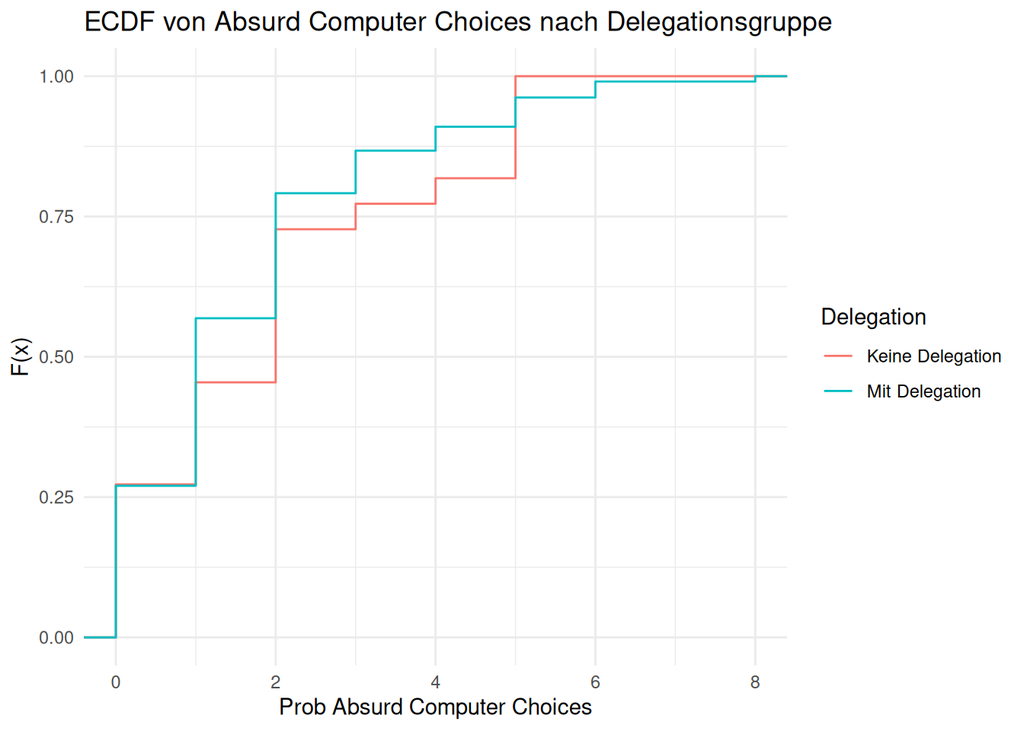

```r
# 1.95 vs 1.649, p = 0.4559
ggplot(analysis_data, aes(x = ProbOfAbsurdComputerChoices, color = DelegationGroup)) +
  stat_ecdf(geom = "step") +
  labs(title = "ECDF von Absurd Computer Choices nach Delegationsgruppe",
       x = "Prob Absurd Computer Choices",
       y = "F(x)",
       color = "Delegation") +
  theme_minimal()
```

```r
ks.test(
  as.numeric(analysis_data$ProbOfAbsurdComputerChoices[analysis_data$DelegationGroup == "Keine Delegation"]),
  as.numeric(analysis_data$ProbOfAbsurdComputerChoices[analysis_data$DelegationGroup == "Mit Delegation"])
) # p = 0.5876
```

```
##
##  Exact two-sample Kolmogorov-Smirnov test
##
## data:  as.numeric(analysis_data$ProbOfAbsurdComputerChoices[analysis_data$DelegationGroup == "Keine Delegation"]) and as.numeric(analysis_data$ProbOfAbsurdComputerChoices[analysis_data$DelegationGroup == "Mit Delegation"])
## D = 0.11417, p-value = 0.5876
## alternative hypothesis: two-sided
```

```r
choices %>%
  distinct(ProlificID, .keep_all = TRUE) %>%
  mutate(
    sumDelegations_group = ifelse(sumDelegations == 0, "sumDelegations = 0", "sumDelegations > 0"),
    hasPositiveProb = ProbOfBadComputerChoices > 0
  ) %>%
  group_by(sumDelegations_group, hasPositiveProb) %>%
  summarise(Anzahl = n(), .groups = "drop") %>%
  pivot_wider(
    names_from = hasPositiveProb,
    values_from = Anzahl,
    names_prefix = "Prob_"
  ) %>%
  mutate(
    Total = Prob_TRUE + Prob_FALSE,
    Prob_TRUE_pct = round(Prob_TRUE / Total * 100, 1),
    Prob_FALSE_pct = round(Prob_FALSE / Total * 100, 1)
  ) %>%
  select(-Total, -Prob_TRUE, -Prob_FALSE)
```

| sumDelegations_group | Prob_TRUE_pct | Prob_FALSE_pct |
| --- | --- | --- |
| sumDelegations = 0 | 95.5 | 4.5 |
| sumDelegations > 0 | 93.4 | 6.6 |

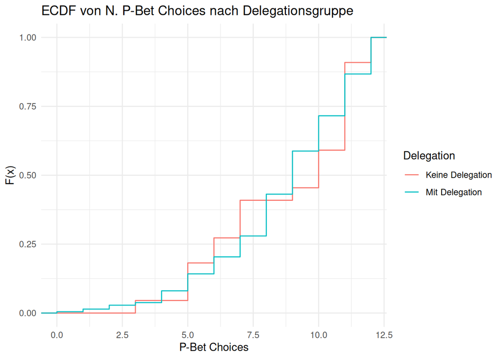

```r
ggplot(analysis_data, aes(x = PBetChoices, color = DelegationGroup)) +
  stat_ecdf(geom = "step") +
  labs(title = "ECDF von N. P-Bet Choices nach Delegationsgruppe",
       x = "P-Bet Choices",
       y = "F(x)",
       color = "Delegation") +
  theme_minimal()
```

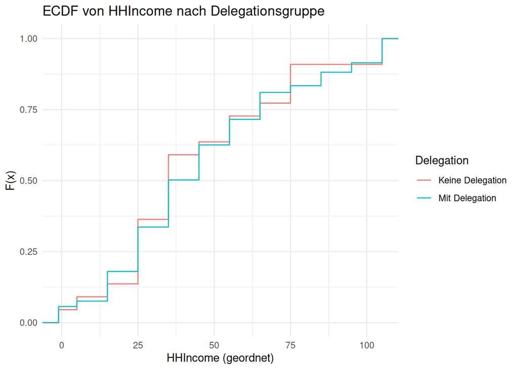

```r
# 1. HHIncome
ggplot(analysis_data, aes(x = HHIncome, color = DelegationGroup)) +
  stat_ecdf(geom = "step") +
  labs(title = "ECDF von HHIncome nach Delegationsgruppe",
       x = "HHIncome (geordnet)",
       y = "F(x)",
       color = "Delegation") +
  theme_minimal()
```

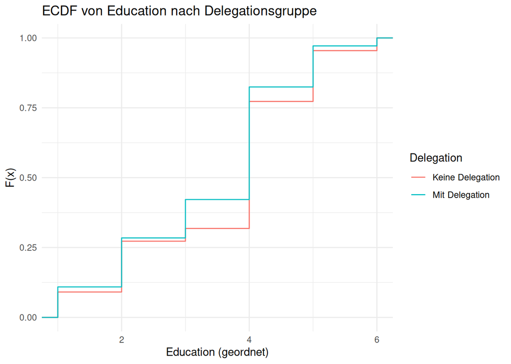

```r
# 2. Education
ggplot(analysis_data, aes(x = Education, color = DelegationGroup)) +
  stat_ecdf(geom = "step") +
  labs(title = "ECDF von Education nach Delegationsgruppe",
       x = "Education (geordnet)",
       y = "F(x)",
       color = "Delegation") +
  theme_minimal()
```

```r
# KS-Test für HHIncome
ks.test(
  as.numeric(analysis_data$HHIncome[analysis_data$DelegationGroup == "Keine Delegation"]),
  as.numeric(analysis_data$HHIncome[analysis_data$DelegationGroup == "Mit Delegation"])
)
```

```
##
##  Exact two-sample Kolmogorov-Smirnov test
##
## data:  as.numeric(analysis_data$HHIncome[analysis_data$DelegationGroup == "Keine Delegation"]) and as.numeric(analysis_data$HHIncome[analysis_data$DelegationGroup == "Mit Delegation"])
## D = 0.088539, p-value = 0.9099
## alternative hypothesis: two-sided
```

```r
# KS-Test für Education
ks.test(
  as.numeric(analysis_data$Education[analysis_data$DelegationGroup == "Keine Delegation"]),
  as.numeric(analysis_data$Education[analysis_data$DelegationGroup == "Mit Delegation"])
)
```

```
##
##  Exact two-sample Kolmogorov-Smirnov test
##
## data:  as.numeric(analysis_data$Education[analysis_data$DelegationGroup == "Keine Delegation"]) and as.numeric(analysis_data$Education[analysis_data$DelegationGroup == "Mit Delegation"])
## D = 0.10362, p-value = 0.6007
## alternative hypothesis: two-sided
```

```r
# Step 1: Filter for non-delegated choices and calculate frequency of non-dominated choices
nonDelegatedChoices <- choices %>%
  filter(Delegated == 0, Option > 0) %>%
  group_by(ProlificID, Algorithm) %>%
  summarise(
    nonDomCount = sum(Nondominated, na.rm = TRUE),
    totalNonDelegated = n(),
    .groups = "drop"
  ) %>%
  mutate(freqNonDom = nonDomCount / totalNonDelegated)

# Step 2: Join with delegation status
nonDelegatedChoices <- nonDelegatedChoices %>%
  left_join(
    choices %>%
      select(ProlificID, sumDelegations) %>%
      distinct(),
    by = "ProlificID"
  )

# Step 3: Group by delegation status and calculate mean frequency
nonDelegatedChoices %>%
  group_by(sumDelegations == 0, Algorithm) %>%
  summarise(
    meanFreqNonDom = mean(freqNonDom, na.rm = TRUE),
    sdFreqNonDom = sd(freqNonDom, na.rm = TRUE),
    n = n(),
    .groups = "drop"
  ) %>%
  mutate(
    delegationGroup = ifelse(`sumDelegations == 0`, "Never-delegators", "Sometimes-delegators")
  ) %>%
  select(delegationGroup, Algorithm, meanFreqNonDom, sdFreqNonDom, n)
```

| delegationGroup | Algorithm | meanFreqNonDom | sdFreqNonDom | n |
| --- | --- | --- | --- | --- |
| Sometimes-delegators | EV | 0.3395089 | 0.2486490 | 96 |
| Sometimes-delegators | Pref | 0.3320142 | 0.2713342 | 74 |
| Never-delegators | EV | 0.3125000 | 0.1613743 | 4 |
| Never-delegators | Pref | 0.3541667 | 0.1780718 | 18 |

### win-stay, lose-shift

```r
choices <- choices %>%
  group_by(ProlificID) %>%
  arrange(WithinPartDecisionNumber, .by_group = TRUE) %>%
  mutate(
    lagDelegated         = lag(Delegated, 1),
    lagRelevantPayoff    = lag(RelevantPayoff, 1),
    lagSatisfactionRating = lag(SatisfactionRating, 1)
  ) %>%
  ungroup()

choices$stay <- 1*(choices$Delegated == choices$lagDelegated)
choices$lagWin <- 1*(choices$RelevantPayoff > 0)

winStayReg <- feols(
  stay ~ EVAlgorithm*lagWin | OptionsetID + WithinPartDecisionNumber,
  cluster = ~ProlificID,
  data = subset(choices, Part == 2 & WithinPartDecisionNumber > 1)
)
```

```
## NOTE: 2 observations removed because of NA values (LHS: 2).
```

```r
summary(winStayReg)
```

```
## OLS estimation, Dep. Var.: stay
## Observations: 1,615
## Fixed-effects: OptionsetID: 8,  WithinPartDecisionNumber: 7
## Standard-errors: Clustered (ProlificID)
##                     Estimate Std. Error   t value Pr(>|t|)
## EVAlgorithm        -0.038714   0.046728 -0.828502 0.408238
## lagWin              0.042733   0.032822  1.301938 0.194229
## EVAlgorithm:lagWin -0.101566   0.049417 -2.055308 0.040969 *
## ---
## Signif. codes:  0 '***' 0.001 '**' 0.01 '*' 0.05 '.' 0.1 ' ' 1
## RMSE: 0.463812     Adj. R2: 0.023765
##                  Within R2: 0.014698
```

```r
winStayReg10 <- feols(
  stay ~ lagDelegated*I(1-lagWin) | OptionsetID + WithinPartDecisionNumber,
  cluster = ~ProlificID,
  data = subset(choices, EVAlgorithm == 1 & Part == 2 & WithinPartDecisionNumber > 1)
)
summary(winStayReg10)
```

```
## OLS estimation, Dep. Var.: stay
## Observations: 819
## Fixed-effects: OptionsetID: 8,  WithinPartDecisionNumber: 7
## Standard-errors: Clustered (ProlificID)
##                             Estimate Std. Error   t value Pr(>|t|)
## lagDelegated               -0.084825   0.060180 -1.409503  0.16134
## I(1 - lagWin)               0.001031   0.055659  0.018526  0.98525
## lagDelegated:I(1 - lagWin)  0.117426   0.072470  1.620344  0.10785
## ---
## Signif. codes:  0 '***' 0.001 '**' 0.01 '*' 0.05 '.' 0.1 ' ' 1
## RMSE: 0.480487     Adj. R2: 0.005125
##                  Within R2: 0.008513
```

```r
winStayReg20 <- feols(
  stay ~ lagDelegated*I(1-lagWin) | OptionsetID + WithinPartDecisionNumber,
  cluster = ~ProlificID,
  data = subset(choices, EVAlgorithm == 0 & Part == 2 & WithinPartDecisionNumber > 1)
)
```

```
## NOTE: 2 observations removed because of NA values (LHS: 2, RHS: 2).
```

```r
summary(winStayReg20)
```

```
## OLS estimation, Dep. Var.: stay
## Observations: 796
## Fixed-effects: OptionsetID: 8,  WithinPartDecisionNumber: 7
## Standard-errors: Clustered (ProlificID)
##                             Estimate Std. Error   t value Pr(>|t|)
## lagDelegated               -0.002146   0.050853 -0.042207  0.96641
## I(1 - lagWin)              -0.015209   0.043524 -0.349451  0.72740
## lagDelegated:I(1 - lagWin) -0.060019   0.067862 -0.884420  0.37833
## ---
## Signif. codes:  0 '***' 0.001 '**' 0.01 '*' 0.05 '.' 0.1 ' ' 1
## RMSE: 0.441256     Adj. R2: 0.020019
##                  Within R2: 0.00407
```

```r
winStayReg2 <- feols(
  stay ~ EVAlgorithm*lagSatisfactionRating | OptionsetID + WithinPartDecisionNumber,
  cluster = ~ProlificID,
  data = subset(choices, Part == 2 & WithinPartDecisionNumber > 1)
)
```

```
## NOTE: 2 observations removed because of NA values (LHS: 2, RHS: 2).
```

```r
summary(winStayReg2)
```

```
## OLS estimation, Dep. Var.: stay
## Observations: 1,615
## Fixed-effects: OptionsetID: 8,  WithinPartDecisionNumber: 7
## Standard-errors: Clustered (ProlificID)
##                                    Estimate Std. Error   t value Pr(>|t|)
## EVAlgorithm                       -0.091518   0.046542 -1.966338 0.050452 .
## lagSatisfactionRating              0.005389   0.008098  0.665476 0.506407
## EVAlgorithm:lagSatisfactionRating -0.001945   0.008211 -0.236832 0.812996
## ---
## Signif. codes:  0 '***' 0.001 '**' 0.01 '*' 0.05 '.' 0.1 ' ' 1
## RMSE: 0.463585     Adj. R2: 0.024721
##                  Within R2: 0.015662
```

```r
choices %>%
  group_by(EVAlgorithm, lagDelegated, lagWin) %>%
  summarise(
    stayRate = mean(stay == 1, na.rm = TRUE),
    n = n(),
    .groups = "drop"
  )
```

| EVAlgorithm | lagDelegated | lagWin | stayRate | n |
| --- | --- | --- | --- | --- |
| 0 | 0 | 0 | 0.7248322 | 149 |
| 0 | 0 | 1 | 0.7394636 | 261 |
| 0 | 1 | 0 | 0.6486486 | 148 |
| 0 | 1 | 1 | 0.7310924 | 238 |
| 0 | NA | 0 | NaN | 38 |
| 0 | NA | 1 | NaN | 77 |
| 1 | 0 | 0 | 0.6326531 | 147 |
| 1 | 0 | 1 | 0.6409266 | 259 |
| 1 | 1 | 0 | 0.6607143 | 168 |
| 1 | 1 | 1 | 0.5469388 | 245 |

[output cut: 2 more lines]

```r
choices %>%
  filter((WithinPartDecisionNumber == 2)) %>%
  group_by(EVAlgorithm, lagDelegated, lagWin) %>%
  summarise(
    stayRate = mean(stay == 1, na.rm = TRUE),
    n = n(),
    .groups = "drop"
  )
```

| EVAlgorithm | lagDelegated | lagWin | stayRate | n |
| --- | --- | --- | --- | --- |
| 0 | 0 | 0 | 0.4615385 | 13 |
| 0 | 0 | 1 | 0.6216216 | 37 |
| 0 | 1 | 0 | 0.7391304 | 23 |
| 0 | 1 | 1 | 0.5897436 | 39 |
| 0 | NA | 0 | NaN | 1 |
| 0 | NA | 1 | NaN | 1 |
| 1 | 0 | 0 | 0.5000000 | 14 |
| 1 | 0 | 1 | 0.5600000 | 25 |
| 1 | 1 | 0 | 0.6451613 | 31 |
| 1 | 1 | 1 | 0.5000000 | 48 |

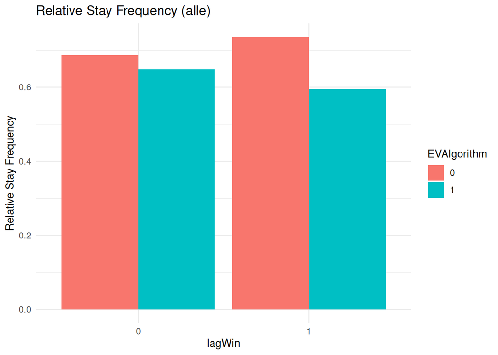

```r
# Basis-Daten (Filter)
df_base <- choices %>%
  filter(WithinPartDecisionNumber > 1)

# Funktion zur Berechnung relativer Stay-Frequenzen
calc_rel_stay <- function(df) {
  df %>%
    group_by(EVAlgorithm, lagWin) %>%
    summarise(rel_stay = mean(stay, na.rm = TRUE),
              n = n(),
              .groups = "drop")
}

# Datensätze
df_all <- calc_rel_stay(df_base)

df_deleg <- df_base %>%
  filter(sumDelegations > 0) %>%
  calc_rel_stay()

p1 <- ggplot(df_all, aes(x = factor(lagWin), y = rel_stay, fill = as.factor(EVAlgorithm))) +
  geom_col(position = "dodge") +
  labs(title = "Relative Stay Frequency (alle)",
       x = "lagWin",
       y = "Relative Stay Frequency",
       fill = "EVAlgorithm") +
  theme_minimal()

# Plot 2: Nur sumDelegations > 0 (Balken)
p2 <- ggplot(df_deleg, aes(x = factor(lagWin), y = rel_stay, fill = as.factor(EVAlgorithm))) +
  geom_col(position = "dodge") +
  labs(title = "Relative Stay Frequency (sumDelegations > 0)",
       x = "lagWin",
       y = "Relative Stay Frequency",
       fill = "EVAlgorithm") +
  theme_minimal()

# Anzeigen
p1
```

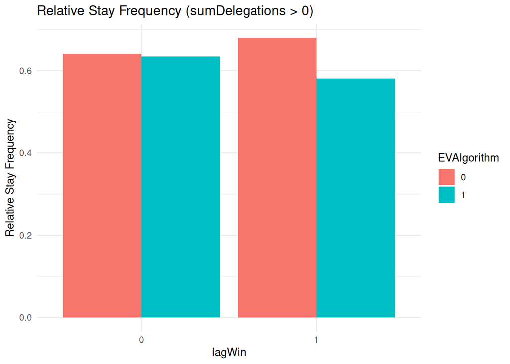

```r
p2
```

### hypothetic choices, never delegate, and reasons

```r
NeverDelegate <- choices %>%
  select(ProlificID, sumDelegations) %>%
  distinct() %>%  # eine Zeile pro Person
  mutate(sumDeleg0 = (sumDelegations == 0))

subjects2 <- subjects %>%
  left_join(NeverDelegate, by = "ProlificID")

subjects2 %>%
  group_by(EVAlgorithm, sumDeleg0) %>%
  summarise(
    SatisfiedPart1 = mean(SatisfiedPart1, na.rm = TRUE),
    n = n(),
    .groups = "drop"
  )
```

| EVAlgorithm | sumDeleg0 | SatisfiedPart1 | n |
| --- | --- | --- | --- |
| 0 | FALSE | 7.556701 | 97 |
| 0 | TRUE | 7.944444 | 18 |
| 1 | FALSE | 7.561404 | 114 |
| 1 | TRUE | 8.000000 | 4 |

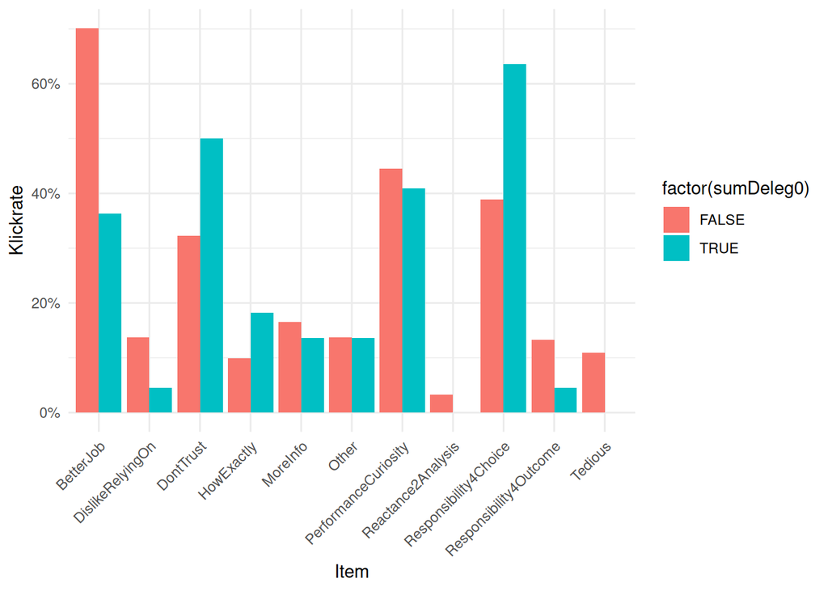

```r
subjects2$SelfHyp10 <- 1-subjects2$DelegateHyp10

subjects_long <- subjects2 %>%
  pivot_longer(
    cols = DontTrust:Other,
    names_to = "item",
    values_to = "clicked"
  )

click_rates_sumDeleg0 <- subjects_long %>%
  group_by(sumDeleg0, item) %>%
  summarise(
    rate = mean(clicked, na.rm = TRUE),
    n = n_distinct(ProlificID),
    .groups = "drop"
  )

ggplot(click_rates_sumDeleg0, aes(x = item, y = rate, fill = factor(sumDeleg0))) +
  # geom_col(fill = "steelblue") +
  geom_col(position = "dodge") +
  scale_y_continuous(labels = percent_format(accuracy = 1)) +
  # facet_wrap(~ sumDeleg0, labeller = labeller(sumDeleg0 = c(`TRUE` = "Never Delegate", `FALSE` = "Delegated"))) +
  labs(x = "Item", y = "Klickrate") +
  theme_minimal() +
  theme(axis.text.x = element_text(angle = 45, hjust = 1))
```

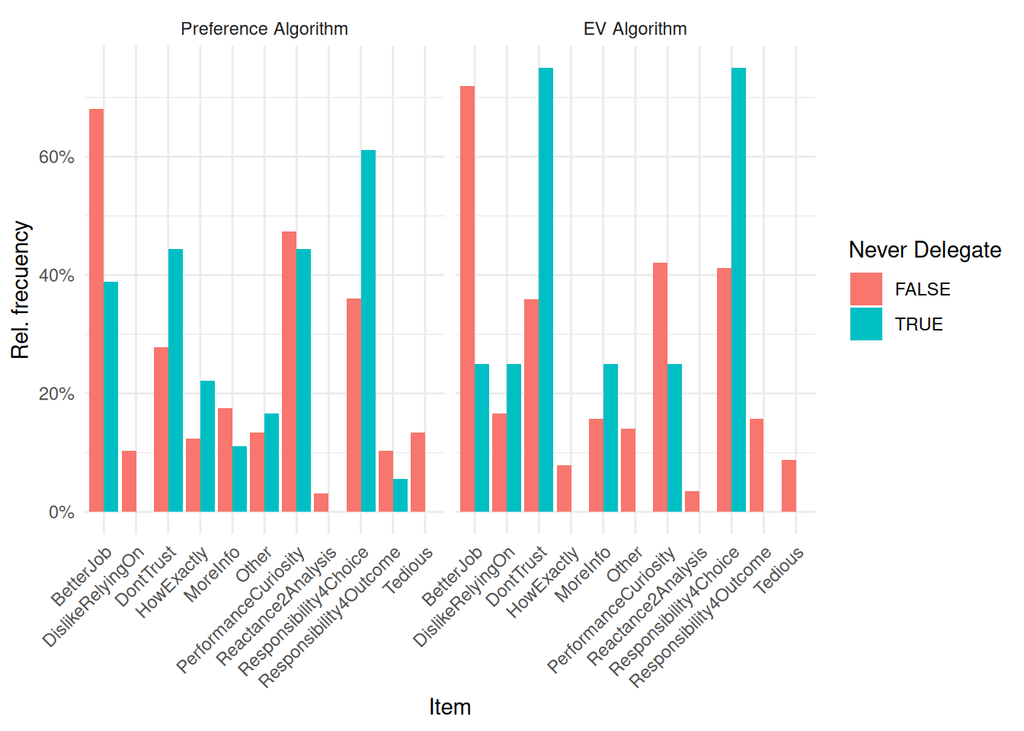

```r
person_level <- subjects_long %>%
  group_by(ProlificID, EVAlgorithm, sumDeleg0, item) %>%
  summarise(
    clicked_person = mean(clicked, na.rm = TRUE),
    .groups = "drop"
  )
click_rates_algo <- person_level %>%
  group_by(EVAlgorithm, sumDeleg0, item) %>%
  summarise(
    rate = mean(clicked_person, na.rm = TRUE),
    n = n(),
    .groups = "drop"
  )


ggplot(click_rates_algo,
       aes(x = item, y = rate, fill = factor(sumDeleg0))) +
  geom_col(position = "dodge") +
  facet_wrap(~ EVAlgorithm,
             labeller = labeller(EVAlgorithm = c(
               `1` = "EV Algorithm",
               `0` = "Preference Algorithm"
             ))) +
  scale_y_continuous(labels = percent_format(accuracy = 1)) +
  labs(x = "Item",
       y = "Rel. frecuency",
       fill = "Never Delegate") +
  theme_minimal() +
  theme(axis.text.x = element_text(angle = 45, hjust = 1))
```

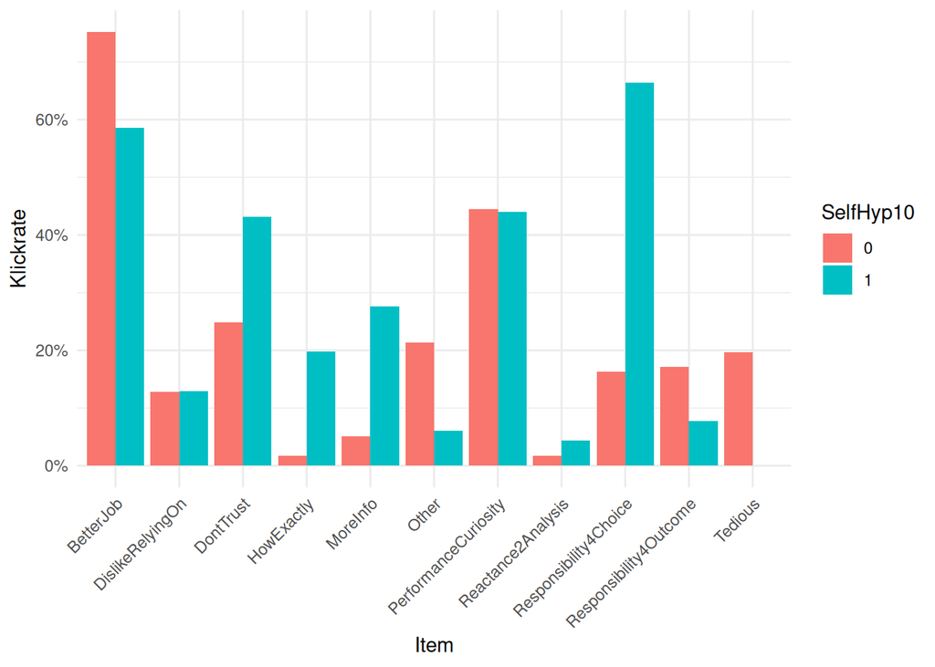

```r
click_rates_DelegateHyp <- subjects_long %>%
  group_by(SelfHyp10, item) %>%
  summarise(
    rate = mean(clicked, na.rm = TRUE),
    n = n_distinct(ProlificID),
    .groups = "drop"
  )

ggplot(click_rates_DelegateHyp, aes(x = item, y = rate, fill = factor(SelfHyp10))) +
  geom_col(position = "dodge") +
  scale_y_continuous(labels = percent_format(accuracy = 1)) +
  labs(x = "Item", y = "Klickrate", fill = "SelfHyp10") +
  theme_minimal() +
  theme(axis.text.x = element_text(angle = 45, hjust = 1))
```

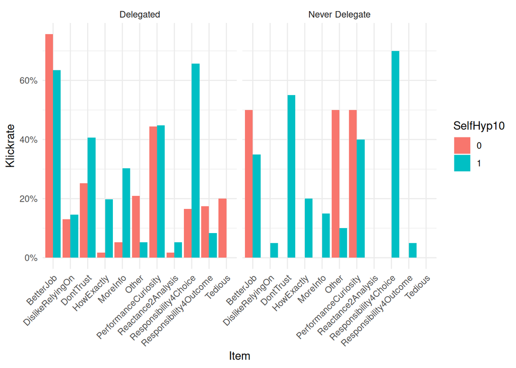

```r
click_rates_both <- subjects_long %>%
  group_by(sumDeleg0, SelfHyp10, item) %>%
  summarise(
    rate = mean(clicked, na.rm = TRUE),
    n = n_distinct(ProlificID),
    .groups = "drop"
  )

ggplot(click_rates_both, aes(x = item, y = rate, fill = factor(SelfHyp10))) +
  geom_col(position = "dodge") +
  facet_wrap(~ sumDeleg0, labeller = labeller(sumDeleg0 = c(`TRUE` = "Never Delegate", `FALSE` = "Delegated"))) +
  scale_y_continuous(labels = percent_format(accuracy = 1)) +
  labs(x = "Item", y = "Klickrate", fill = "SelfHyp10") +
  theme_minimal() +
  theme(axis.text.x = element_text(angle = 45, hjust = 1))
```

if at all, never-delegators are more satisfied with their Part-1 choices.

### Reasons for non-delegation

- die Teil-1-Entscheidungen waren voller fehlerhafter Entscheidungen [measurement nach T1: wie zufrieden/sicher? waren Sie sich mit/in ihren Entscheidungen?] Done. Für die einzelnen Entscheidungen: Je sicherer ich in Teil 1 bzgl. der Entscheidung war, desto eher werde ich an den EV-Algorithmus delegieren (?!?), kein Zusammenhang für den PrefAlgorithm.
- ich traue dem Algorithmus nicht zu, meine Präferenzen einzufangen [measurement? Wahrscheinlichkeiten für einen hypothetischen Teil wie beim 1. Exp?] -> ProbOfBadChoices haben keinen Einfluss auf Never-delegation, aber:

EVAlgorithm -0.036028 0.203132 -0.177362 0.85937853  
WithinPartDecisionNumber -0.009924 0.005705 -1.739501 0.08327301 . Confidence.y -0.023419 0.013064 -1.792664 0.07432937 . ProbOfAbsurdComputerChoices 0.006830 0.018303 0.373168 0.70936379  
ProbOfBadComputerChoices -0.058319 0.016170 -3.606519 0.00037995 * P105_count 0.004795 0.012610 0.380233 0.70412009  
EVAlgorithm:WithinPartDecisionNumber -0.012264 0.008335 -1.471492 0.14251336  
EVAlgorithm:Confidence.y 0.041738 0.016028 2.604073 0.00980698 EVAlgorithm:ProbOfAbsurdComputerChoices -0.070006 0.022913 -3.055368 0.00251080 ** EVAlgorithm:ProbOfBadComputerChoices 0.034684 0.020373 1.702429 0.09001442 .

-> im Pref-Alg: je sicherer ich in meiner Lottery-Choice war, desto weniger delegiere ich (p = 0.074) -> im EV-Alg: andersherum! -> ausserdem: Je eher ich dem Computer schlechte Entscheidungen zutraue, desto weniger delegiere ich im Pref-Alg, während im EV-Alg die Angst vor absurden Entscheidungen Delegation verhindert (Das kommt nicht daher, dass im EV-Alg-Trmt keine hohen ProbOfAbsurdComputerChoices vorkommen - das EV-Alg-Trmt first order stochastically dominates the Pref-based treatment in terms of this variable!)

```r
table(analysis_data$EVAlgorithm, analysis_data$ProbOfAbsurdComputerChoices)
```

```
##
##      0  1  2  3  4  5  6  8
##   0 31 38 25  6  5  7  2  1
##   1 32 29 28 11  5  8  4  1
```

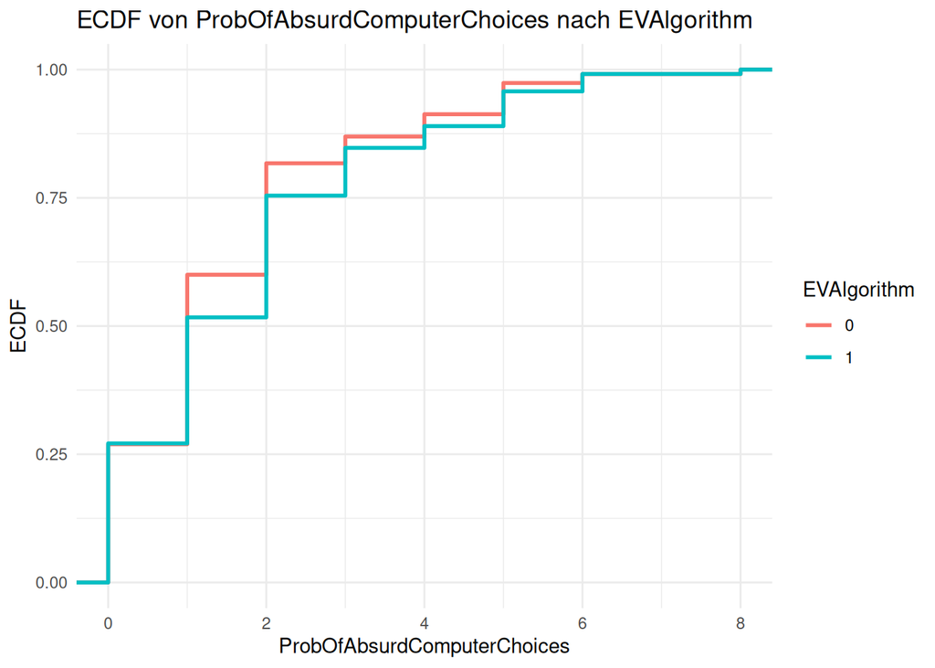

```r
ggplot(analysis_data,
       aes(x = ProbOfAbsurdComputerChoices,
           color = factor(EVAlgorithm))) +
  stat_ecdf(size = 1) +
  labs(
    x = "ProbOfAbsurdComputerChoices",
    y = "ECDF",
    color = "EVAlgorithm",
    title = "ECDF von ProbOfAbsurdComputerChoices nach EVAlgorithm"
  ) +
  theme_minimal()
```

- ich traue dem Algorithmus zu gut zu, meine Präferenzen einzufangen, und das schreckt mich ab [vermutlich das gleiche measurement wie eben] -> eher nein, denn das würde bedeuten, dass bei ProbOfBadComputerChoices == 0 Delegation niedriger wäre als bei höheren Werten, aber das Gegenteil ist der Fall.

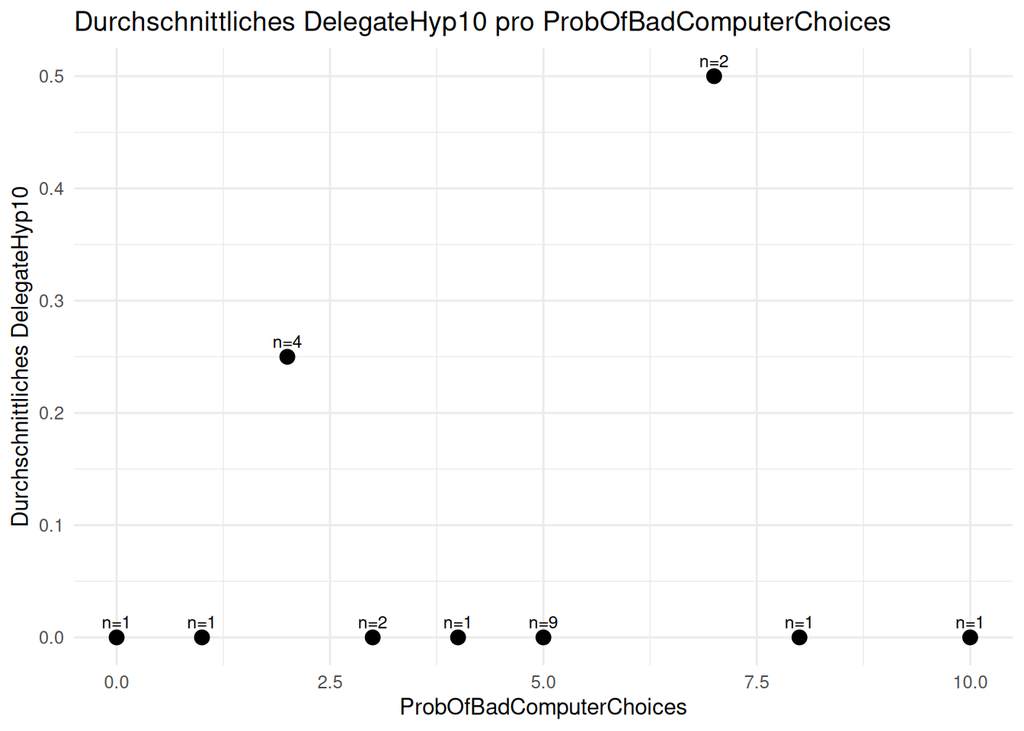

```r
# 1. ProbOfBadComputerChoices pro Person aus choices
person_data <- choices %>%
  group_by(ProlificID) %>%
  summarise(ProbOfBadComputerChoices = first(ProbOfBadComputerChoices)) %>%
  ungroup()

# Mit DelegateHyp10 und sumDeleg0 joinen
plot_data <- person_data %>%
  left_join(subjects %>% select(ProlificID, DelegateHyp10), by = "ProlificID") %>%
  left_join(NeverDelegate %>% select(ProlificID, sumDeleg0), by = "ProlificID") %>%
  filter(sumDeleg0 == TRUE)   # nur Personen, die sumDeleg0 == TRUE haben

# 3. Mitteln pro ProbOfBadComputerChoices
avg_data <- plot_data %>%
  group_by(ProbOfBadComputerChoices) %>%
  summarise(
    DelegateHyp10_mean = mean(DelegateHyp10, na.rm = TRUE),
    n = n()
  )

ggplot(avg_data, aes(x = ProbOfBadComputerChoices, y = DelegateHyp10_mean)) +
  geom_point(size = 3) +
  geom_text(aes(label = paste0("n=", n)), vjust = -0.7, size = 3) +
  labs(
    title = "Durchschnittliches DelegateHyp10 pro ProbOfBadComputerChoices",
    x = "ProbOfBadComputerChoices",
    y = "Durchschnittliches DelegateHyp10"
  ) +
  theme_minimal()
```

-> für die NeverDelegators kann man es nicht so wirklich angucken (die delegieren ja nicht); Auch in der DelegateHyp10 haben die meisten eine 0, da gibt es keinen klaren Zusammenhang

- ich will nicht von Algorithmen analysiert werden -> wird von keinem NeverDelegator als Grund angeführt, auch unter den anderen so gut wie nie angeklickt.
- ich will nicht, dass Algorithmen mir in meine Entscheidungen ’reinpfuschen -> wird von wenigen angeklickt (unter den NeverDelegators noch weniger)
- Do we have any measure of how complex the lottery-selection task was in people’s view? -> anecdotal from the comments: many said time was not enough to make a good decision
- Do we have numbers on average payoffs as a function of AR, by treatment?

```r
library(doBy)
summaryBy (RelevantPayoff ~ Delegated, choices)
```

| Delegated | RelevantPayoff.mean |
| --- | --- |
| 0 | 195.1786 |
| 1 | 243.4940 |

-> on average, delegation led to a payoff of 243.49 points, non-delegation to a payoff of 195.18 points (25% increase!)

```r
  subjects2$OtherText[subjects2$sumDeleg0 == 1]
```

```
##  [1] ""
##  [2] ""
##  [3] ""
##  [4] ""
##  [5] "It's more fun to choose it myself"
##  [6] ""
##  [7] ""
##  [8] "I am having fun with this and enjoy the risk"
##  [9] ""
## [10] ""
## [11] ""
## [12] ""
## [13] ""
## [14] "I'm just happy to see what happens"
## [15] ""
## [16] ""
## [17] ""
## [18] ""
## [19] ""
## [20] ""
## [21] ""
## [22] ""
```

```r
  subjects2$Other[subjects2$sumDeleg0 == 1]
```

```
##  [1] 0 0 0 0 1 0 0 1 0 0 0 0 0 1 0 0 0 0 0 0 0 0
```

```r
  subjects2$OtherText[subjects2$sumDeleg0 == 0]
```

```
##   [1] "I analytically quickly analysed and trusted my own judgement, and the more risk averse likely scenarios."
##   [2] "I felt that with the limited time to make decisions the computer is better suited to calculate the best option to select. "
##   [3] ""
##   [4] "not enough time given to fully anaylse data myself"
##   [5] ""
##   [6] ""
##   [7] ""
##   [8] ""
##   [9] ""
##  [10] ""
##  [11] ""
##  [12] ""
##  [13] "I would need more time to view all the options available"
##  [14] "It is just more interesting and gives me something to do in the task. There didn't appear to be much in the way of massive outliers in the payoffs tough some were clearly superior options to others. The most annoying thing is the way you designed the experiment, I obviously misclicked on o…
##  [15] "it was a lot of info to absorb in the time available!"
```

[output cut: 196 more lines]